# Practical Machine Learning Project

ALVARO RODRIGUEZ PEREZ

3 de octubre de 2017

## INTRODUCTION

This model consists on a implementation of two models: Regression Tree and Random Forest using a dataset provided no Practical Machine Learning Project.

Project consists in create a classification model to determine a “Classe” Variavel referred to the “how well an exercise training was”.

# IMPORTING DATA

In order to avoid error of importation with missing values. Its importante set na.string option with some characters related to missing values (NA,#DIV/0,“”) to help R importation function a correct determination of each type of variavels.

```r
setwd("~/Curso Coursera/Machile Learning/Trabajo")
library(caret)
```

```r
library(VIM) #missing values maps
training<- read.csv("pml-training.csv", header=TRUE, dec="."
                    ,na.strings = c("NA", "#DIV/0!", ""))

testing <- read.csv("pml-testing.csv", header=TRUE, dec=".",
                    na.strings = c("NA", "#DIV/0!", ""))
```

## Data Cleaning

Testing and Training datasets have a lot of columns with missings values. In order to clean its, I identify columns with missing values in Testing Set and deleted in both Training and Testing Data sets because testing set have more columns with missing values than training set.

Thus, columns 1 to 7 was removed in both datasets because don’t have relationship with outcome

```r
# cleaning data:

features <- names(testing[,colSums(is.na(testing)) == 0]) # columnas sin NAs
features <- features[-60]


training1<- training[,c(features,"classe")]
training1<- training1[,-(1:7)]


testing1<- testing[,c(features,"problem_id")]
testing1<- testing1[,-(1:7)]


dim(testing1)
```

```
## [1] 20 53
```

```r
dim(training1)
```

```
## [1] 19622    53
```

## Missing Values Maps

Missing Maps shows no presence of NAs

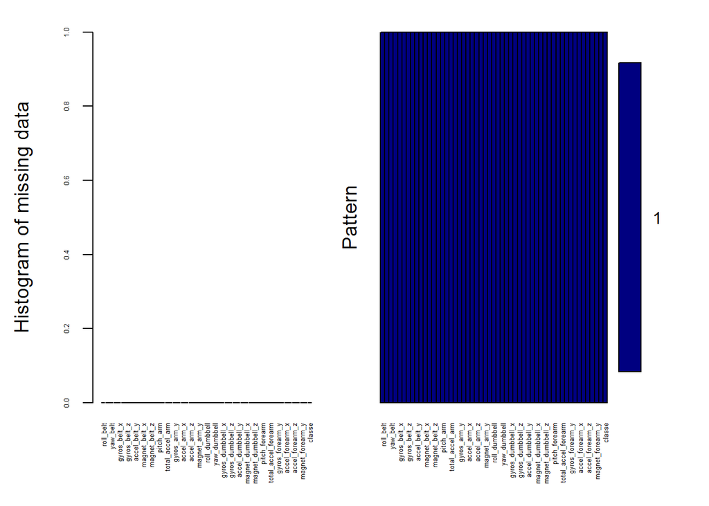

```
##
##  Variables sorted by number of missings:
##              Variable Count
##             roll_belt     0
##            pitch_belt     0
##              yaw_belt     0
##      total_accel_belt     0
##          gyros_belt_x     0
##          gyros_belt_y     0
##          gyros_belt_z     0
##          accel_belt_x     0
##          accel_belt_y     0
##          accel_belt_z     0
##         magnet_belt_x     0
##         magnet_belt_y     0
##         magnet_belt_z     0
##              roll_arm     0
##             pitch_arm     0
##               yaw_arm     0
##       total_accel_arm     0
##           gyros_arm_x     0
##           gyros_arm_y     0
##           gyros_arm_z     0
##           accel_arm_x     0
##           accel_arm_y     0
##           accel_arm_z     0
##          magnet_arm_x     0
##          magnet_arm_y     0
##          magnet_arm_z     0
##         roll_dumbbell     0
##        pitch_dumbbell     0
##          yaw_dumbbell     0
##  total_accel_dumbbell     0
##      gyros_dumbbell_x     0
##      gyros_dumbbell_y     0
##      gyros_dumbbell_z     0
##      accel_dumbbell_x     0
##      accel_dumbbell_y     0
##      accel_dumbbell_z     0
##     magnet_dumbbell_x     0
##     magnet_dumbbell_y     0
##     magnet_dumbbell_z     0
##          roll_forearm     0
##         pitch_forearm     0
##           yaw_forearm     0
##   total_accel_forearm     0
##       gyros_forearm_x     0
##       gyros_forearm_y     0
##       gyros_forearm_z     0
##       accel_forearm_x     0
##       accel_forearm_y     0
##       accel_forearm_z     0
##      magnet_forearm_x     0
##      magnet_forearm_y     0
##      magnet_forearm_z     0
##                classe     0
```

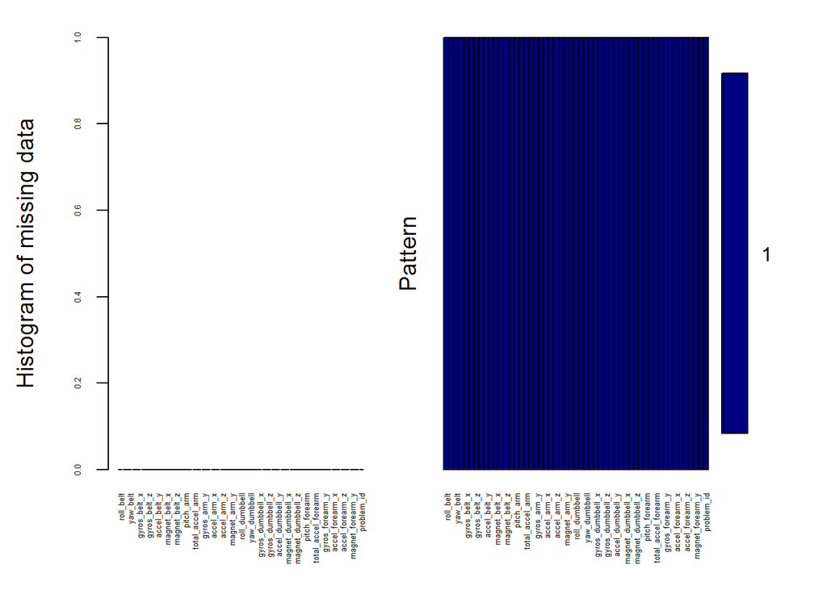

```
##
##  Variables sorted by number of missings:
##              Variable Count
##             roll_belt     0
##            pitch_belt     0
##              yaw_belt     0
##      total_accel_belt     0
##          gyros_belt_x     0
##          gyros_belt_y     0
##          gyros_belt_z     0
##          accel_belt_x     0
##          accel_belt_y     0
##          accel_belt_z     0
##         magnet_belt_x     0
##         magnet_belt_y     0
##         magnet_belt_z     0
##              roll_arm     0
##             pitch_arm     0
##               yaw_arm     0
##       total_accel_arm     0
##           gyros_arm_x     0
##           gyros_arm_y     0
##           gyros_arm_z     0
##           accel_arm_x     0
##           accel_arm_y     0
##           accel_arm_z     0
##          magnet_arm_x     0
##          magnet_arm_y     0
##          magnet_arm_z     0
##         roll_dumbbell     0
##        pitch_dumbbell     0
##          yaw_dumbbell     0
##  total_accel_dumbbell     0
##      gyros_dumbbell_x     0
##      gyros_dumbbell_y     0
##      gyros_dumbbell_z     0
##      accel_dumbbell_x     0
##      accel_dumbbell_y     0
##      accel_dumbbell_z     0
##     magnet_dumbbell_x     0
##     magnet_dumbbell_y     0
##     magnet_dumbbell_z     0
##          roll_forearm     0
##         pitch_forearm     0
##           yaw_forearm     0
##   total_accel_forearm     0
##       gyros_forearm_x     0
##       gyros_forearm_y     0
##       gyros_forearm_z     0
##       accel_forearm_x     0
##       accel_forearm_y     0
##       accel_forearm_z     0
##      magnet_forearm_x     0
##      magnet_forearm_y     0
##      magnet_forearm_z     0
##            problem_id     0
```

## Data Partition

I created a train and test datasets based in training data set with a proportion of 70/30. Train Set will be for training model proposes and Test Set for Validation proposes

```r
# datapartition

set.seed(33)
inTrain<- createDataPartition(training1$classe, p=0.7, list=FALSE)
train<- training1[inTrain,]
test<- training1[-inTrain,]
```

## RPART Model

Next step, creation of a decition tree model: RPART

```r
# modelo RPART:

modFit1<- train(classe~., data=train, method= "rpart",
               trControl=trainControl(method="cv", number=10))
modFit1$finalModel
```

```
## n= 13737
##
## node), split, n, loss, yval, (yprob)
##       * denotes terminal node
##
##  1) root 13737 9831 A (0.28 0.19 0.17 0.16 0.18)
##    2) roll_belt< 130.5 12588 8692 A (0.31 0.21 0.19 0.18 0.11)
##      4) pitch_forearm< -34.35 1082    4 A (1 0.0037 0 0 0) *
##      5) pitch_forearm>=-34.35 11506 8688 A (0.24 0.23 0.21 0.2 0.12)
##       10) magnet_dumbbell_y< 438.5 9721 6958 A (0.28 0.18 0.24 0.19 0.11)
##         20) roll_forearm< 123.5 6032 3561 A (0.41 0.18 0.18 0.17 0.06) *
##         21) roll_forearm>=123.5 3689 2466 C (0.079 0.18 0.33 0.22 0.19) *
##       11) magnet_dumbbell_y>=438.5 1785  878 B (0.031 0.51 0.043 0.23 0.18) *
##    3) roll_belt>=130.5 1149   10 E (0.0087 0 0 0 0.99) *
```

```r
pred1<- predict(modFit1, test)

confusionMatrix(test$classe, pred1)
```

```
## Confusion Matrix and Statistics
##
##           Reference
## Prediction    A    B    C    D    E
##          A 1524   32  114    0    4
##          B  474  386  279    0    0
##          C  490   32  504    0    0
##          D  438  156  370    0    0
##          E  160  160  270    0  492
##
## Overall Statistics
##
##                Accuracy : 0.4938
##                  95% CI : (0.4809, 0.5067)
##     No Information Rate : 0.5244
##     P-Value [Acc > NIR] : 1
##
##                   Kappa : 0.338
##  Mcnemar's Test P-Value : NA
##
## Statistics by Class:
##
##                      Class: A Class: B Class: C Class: D Class: E
## Sensitivity            0.4938  0.50392  0.32791       NA  0.99194
## Specificity            0.9464  0.85290  0.87994   0.8362  0.89052
## Pos Pred Value         0.9104  0.33889  0.49123       NA  0.45471
## Neg Pred Value         0.6291  0.91993  0.78740       NA  0.99917
## Prevalence             0.5244  0.13016  0.26117   0.0000  0.08428
## Detection Rate         0.2590  0.06559  0.08564   0.0000  0.08360
## Detection Prevalence   0.2845  0.19354  0.17434   0.1638  0.18386
## Balanced Accuracy      0.7201  0.67841  0.60393       NA  0.94123
```

Accuracy (49%) shows a low Performance model explined but a lot of “classes” in dataset. So we try to implement another model ussing Rando Forest.

## Random Forest Model

In order to improve a performance of a model, i set RF Model with Cross Validation ands 10 folds:

```r
# modelo Ramdom forest

modFit2<- train(classe~., data=train, method= "rf"
               , trControl= trainControl(method="cv",number=10))
modFit2$finalModel
```

```
##
## Call:
##  randomForest(x = x, y = y, mtry = param$mtry)
##                Type of random forest: classification
##                      Number of trees: 500
## No. of variables tried at each split: 27
##
##         OOB estimate of  error rate: 0.76%
## Confusion matrix:
##      A    B    C    D    E class.error
## A 3900    5    1    0    0 0.001536098
## B   21 2626   11    0    0 0.012039127
## C    0   15 2369   12    0 0.011268781
## D    0    1   22 2228    1 0.010657194
## E    0    0    6   10 2509 0.006336634
```

```r
pred2<- predict(modFit2, test)

confusionMatrix(test$classe, pred2)
```

```
## Confusion Matrix and Statistics
##
##           Reference
## Prediction    A    B    C    D    E
##          A 1670    3    0    0    1
##          B    7 1125    7    0    0
##          C    0    3 1020    3    0
##          D    0    0   19  943    2
##          E    0    1    2    0 1079
##
## Overall Statistics
##
##                Accuracy : 0.9918
##                  95% CI : (0.9892, 0.994)
##     No Information Rate : 0.285
##     P-Value [Acc > NIR] : < 2.2e-16
##
##                   Kappa : 0.9897
##  Mcnemar's Test P-Value : NA
##
## Statistics by Class:
##
##                      Class: A Class: B Class: C Class: D Class: E
## Sensitivity            0.9958   0.9938   0.9733   0.9968   0.9972
## Specificity            0.9990   0.9971   0.9988   0.9957   0.9994
## Pos Pred Value         0.9976   0.9877   0.9942   0.9782   0.9972
## Neg Pred Value         0.9983   0.9985   0.9942   0.9994   0.9994
## Prevalence             0.2850   0.1924   0.1781   0.1607   0.1839
## Detection Rate         0.2838   0.1912   0.1733   0.1602   0.1833
## Detection Prevalence   0.2845   0.1935   0.1743   0.1638   0.1839
## Balanced Accuracy      0.9974   0.9954   0.9860   0.9963   0.9983
```

Accuracy in confusion matrix Test DataSet increased a lot, obtaining 99,18%.This model is a best classificator.

IN ORDER TO ASWWER THE QUESTION OF A PROJECT: THE OUT OF SAMPLE ERROR (GERENALIZATION ERROR) in this case its 0,82% and its obtained like an inverse of accuracy in test dataset (1- 99,18%).

We can’t estimate the out of sample error in testing dataset because don’t have the real outcome values. But analising we want expect that both datasets ( training and testing) could not have a diferent estructure or another variavel who can suspect me to detect that a model doesn’t works.

## Predicting values for Testing Set

So, Finally, predicting values for Testing dataSet are obtained as follow:

```r
# predict in Testing Set for evaluation:

resultsRF<-predict(modFit2,testing1)

resultsRF
```

```
##  [1] B A B A A E D B A A B C B A E E A B B B
## Levels: A B C D E
```

## PRINCIPAL CONCLUSIONS

Thanks!.